# R Notebook

```r
library(readr)
library(dplyr)
library(ggplot2)
library(purrr)
library(ggbeeswarm)
library(scales)
library(stringr)
library(jsonlite)
library(forcats)
library(ggbreak)
```

```r
bgc_class <- read_tsv("./data/2025-01-16-1256-bgc_class_ref.tsv") %>% select(!owner_id)
class_to_cat <- bgc_class$bgc_category
names(class_to_cat) <- bgc_class$class_name

bgc_tax <- read_tsv("./data/2025-01-16-1522-cyano_bgc_tax.tsv")
protos <- read_tsv("./data/2025-01-14-1801-cyano_protoclusters.tsv")
regions <- read_tsv("./data/2025-01-14-1850-cyano_as_regions.tsv") %>%
    mutate(classes = map(region_class, function(class_string) (
        if ( str_starts(class_string, fixed("[")) )
            fromJSON(class_string)
        else
            c(class_string)
    ))) %>%
    mutate(categories = classes %>% map(function(cls_vec) (
        map_vec(cls_vec, function(cls_str) class_to_cat[[cls_str]]) %>% unique() %>% sort())
    )) %>%
    mutate(cats_str = categories %>% map_chr(function(x) str_flatten(x, collapse = ", "))) %>%
    add_count(cats_str) %>%
    mutate(cats_str = forcats::fct_reorder(cats_str, desc(n)),
           class_str = classes %>% map_chr(function(x) str_flatten(x, collapse = ", ")))
as_smc_bgcs <- read_tsv("./data/2025-01-14-1927-cyano_as_bgcs.tsv")
```

# Meeting notes

[~] Remove the saccharides - They got lumped in the “All other” category, easier than figuring out how to deal with hybrid-saccharides [x] Add category for “NRPS-PKS” [x] Grab which ones are 243kb [ ] Play with dimensions / sub-plots to show the smaller lengths (indep. cutoff for each category) [x] Bundle the category combinations below some cutoff (use “other”? see how it looks) [x] Stick with barplot [x] DON’T bother log-transforming Y-axis [ ] Add letters to each facet [x] Export the summary tables as TSVs [ ] Put it up on GitHub and send link [x] Stacked barplot of total BGCs divided by tax_genus [x] Do top 10 genera by count if we somehow have tons of cyano genera [x] JUST stick with Cyanos for now

[ ] ~4-5 sentence Bio for me and Dan

[x] How many specific NRP-metallophores in Cyanos? - 686 protoclusters - 684 regions

# Regions

```r
regions
```

| region_gene_id | bgc_id | region_length | contig_name | region_start_nt | region_end_nt | bgc_annotation_id | region_class | region_category | classes | categories | cats_str | n | class_str |
| --- | --- | --- | --- | --- | --- | --- | --- | --- | --- | --- | --- | --- | --- |
| 575872932 | 3081513 | 16814 | NEXP01000049.1 | 46962 | 63775 | 14563221 | cdps | NA |  |  | NRP | 6616 | cdps |
| 635331769 | 3482373 | 20987 | NZ_LAHA01000037.1 | 44703 | 65689 | 16342627 | terpene | NA |  |  | Terpene | 9279 | terpene |
| 635332829 | 3482379 | 14086 | NZ_LAHA01000037.1 | 92284 | 106369 | 16342658 | ["cyanobactin", "ripp-like"] | NA |  |  | RiPP | 7131 | cyanobactin, ripp-like |
| 635371132 | 3482586 | 20294 | NZ_LAHG01000005.1 | 24742 | 45035 | 16343671 | microviridin | NA |  |  | RiPP | 7131 | microviridin |
| 636020389 | 3486184 | 29354 | NZ_NHAI01000051.1 | 721 | 30074 | 16360826 | crocagin | NA |  |  | RiPP | 7131 | crocagin |
| 636025696 | 3486218 | 29633 | NZ_NHAG01000062.1 | 18748 | 48380 | 16360981 | crocagin | NA |  |  | RiPP | 7131 | crocagin |
| 636046943 | 3486329 | 7305 | NZ_NMQA01000224.1 | 1 | 7305 | 16361543 | hgle-ks | NA |  |  | Polyketide | 3948 | hgle-ks |
| 637232090 | 3493204 | 51561 | NZ_PVWK01000125.1 | 1 | 51561 | 16394191 | t2pks | NA |  |  | Polyketide | 3948 | t2pks |
| 913471060 | 5400445 | 22738 | CANHDI010000029.1 | 1 | 22738 | 25194042 | nrps-like | NA |  |  | NRP | 6616 | nrps-like |
| 913977058 | 5403497 | 4332 | CANLCW010000413.1 | 1 | 4332 | 25207981 | nrps | NA |  |  | NRP | 6616 | nrps |

[output cut: 990 more lines]

```r
region_summary <- regions %>%
    group_by(cats_str) %>%
    mutate(n = n()) %>%
    group_by(cats_str, n) %>%
    summarize_at(
        .vars = vars(region_length),
        .funs = list(
            min_len = min,
            max_len = max,
            mean_len = mean,
            median_len = median,
            sd = sd
            )
        ) %>%
    arrange(desc(n))

region_summary
```

| cats_str | n | min_len | max_len | mean_len | median_len | sd |
| --- | --- | --- | --- | --- | --- | --- |
| Terpene | 9279 | 1038 | 42213 | 17369.37 | 20547.0 | 5721.044 |
| RiPP | 7131 | 1012 | 76778 | 21784.87 | 21218.0 | 11410.315 |
| NRP | 6616 | 1008 | 110333 | 28015.55 | 28412.5 | 18668.193 |
| Polyketide | 3948 | 1067 | 120869 | 30703.07 | 32167.0 | 17091.358 |
| NRP, Polyketide | 2935 | 2829 | 194684 | 53234.38 | 51182.0 | 26613.886 |
| Other | 923 | 1166 | 60885 | 19875.23 | 17853.0 | 10322.775 |
| NRP, RiPP | 326 | 3246 | 243212 | 47720.25 | 47966.0 | 27103.459 |
| NRP, Other | 225 | 3934 | 102276 | 49336.06 | 46488.0 | 24325.664 |
| NRP, Other, Polyketide | 93 | 6955 | 187442 | 64229.83 | 50779.0 | 35054.708 |
| NRP, Other, RiPP | 93 | 18508 | 105102 | 74091.10 | 70439.0 | 20724.165 |

[output cut: 16 more lines]

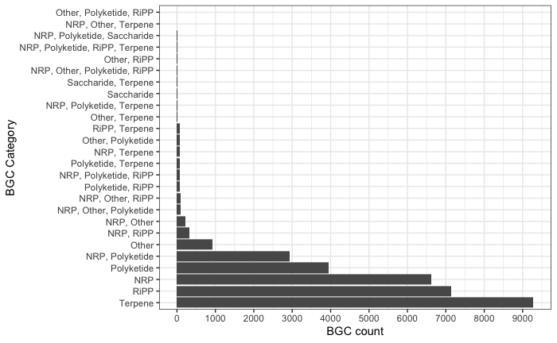

```r
write_tsv(region_summary, "./region_summary.tsv")

# Purely informational plot -- Not needed for pub (since we have the table for it)
category_counts <- region_summary %>%
    ggplot(aes(y = reorder(cats_str, desc(n)))) +
        geom_col(aes(x = n)) +
        scale_x_continuous(name = "BGC count", breaks = seq(0,10000,1000)) +
        scale_y_discrete(name = "BGC Category") +
        theme_bw()
category_counts
ggsave("./figs/__category_counts.svg", category_counts, device = "svg")
ggsave("./figs/__category_counts.png", category_counts, device = "png")
```

Plot the number of BGCs by category - lumping all hybrids except NRPS-PKS

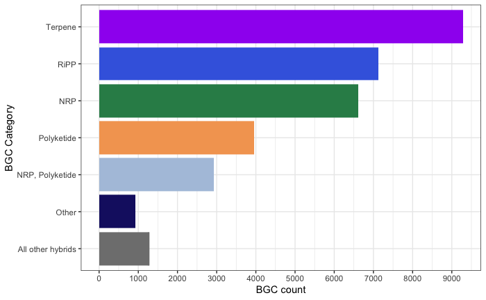

```r
# Lump any hybrid category with fewer than 500 BGCs into an "all other" category
region_summary_lumped <- region_summary %>%
    mutate(group = if_else(n < 500, "All other hybrids", cats_str),
           group = group %>% fct_reorder(n))

# Keep a reference DF handy for which categories got lumped
lump_groups <- region_summary_lumped %>% select(cats_str, group)

# Use the MIBiG / antiSMASH coloring scheme
cat_colors <- c(
    "Polyketide" = "#f4a460",
    "NRP" = "#2e8b57",
    "RiPP" = "#4169e1",
    "Terpene" = "purple",
    "Saccharide" = "#deb887",
    "Other" = "#191970",
    "NRP, Polyketide" = "lightsteelblue",
    "All other hybrids" = "gray50"
)

# Plot it
lumped_category_counts <- region_summary_lumped %>%
    ggplot(aes(y = reorder(group, n))) +
        geom_col(aes(x = n, fill = group)) +
        scale_x_continuous(name = "BGC count", breaks = seq(0,10000,1000)) +
        scale_y_discrete(name = "BGC Category") +
        scale_fill_manual(values = cat_colors) +
        theme_bw() +
        guides(fill = FALSE)
lumped_category_counts
ggsave("./figs/lumped_category_counts.svg", lumped_category_counts, device = "svg")
ggsave("./figs/lumped_category_counts.png", lumped_category_counts, device = "png")
```

Plot the distribution of BGC lengths by category (or combination of categories)

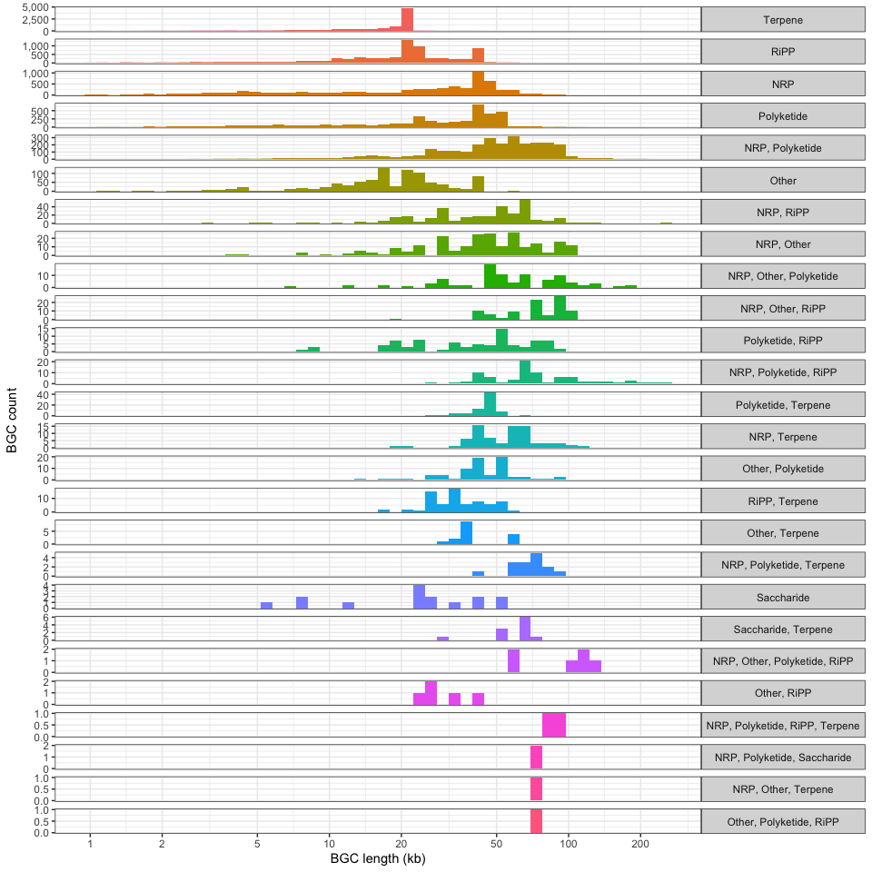

```r
my_breaks <- c(1, 1000, 2000, 5000, 10000, 20000, 50000, 100000, 200000, 500000)

region_hist <- ggplot(regions %>% left_join(lump_groups, by = 'cats_str'), aes(
    x = region_length / 1000,
    # y = categories
)) +
    geom_histogram(aes(fill=cats_str), bins=50) +
    scale_x_log10(name = "BGC length (kb)", breaks = my_breaks / 1000, labels = label_comma()) +
    scale_y_continuous(name = "BGC count", breaks = breaks_extended(n=4), labels = label_comma()) +
    facet_grid(rows = vars(cats_str), scales = "free_y") +
    theme_bw() +
    theme(strip.text.y.right = element_text(angle = 0)) +
    guides(fill = FALSE)

region_hist
```

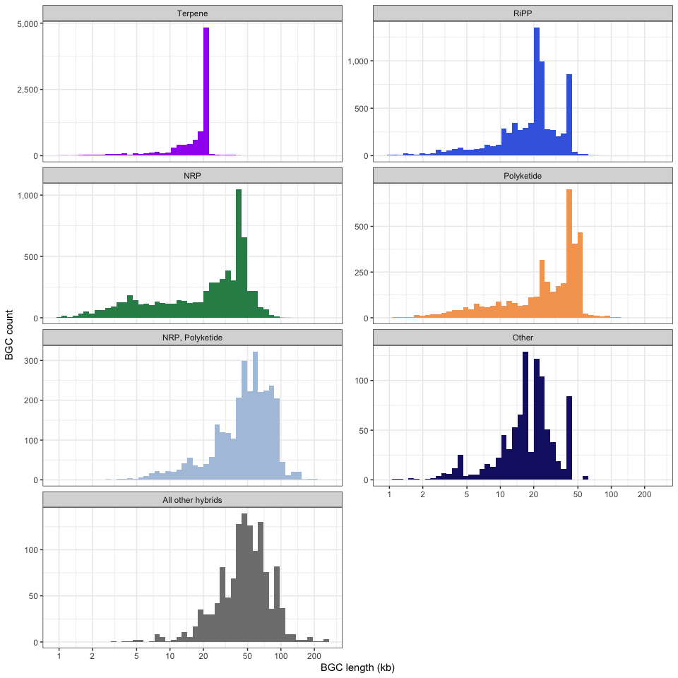

```r
ggsave("./figs/region_hist.svg", region_hist, device = "svg")
ggsave("./figs/region_hist.png", region_hist, device = "png")
region_hist_lumped <- ggplot(regions %>% left_join(lump_groups, by = 'cats_str'), aes(
    x = region_length / 1000,
    # y = categories
)) +
    geom_histogram(aes(fill=group), bins=50) +
    scale_x_log10(name = "BGC length (kb)", breaks = my_breaks / 1000, labels = label_comma()) +
    scale_y_continuous(name = "BGC count", breaks = breaks_extended(n=4), labels = label_comma()) +
    scale_fill_manual(values = cat_colors) +
    facet_wrap(vars(group), ncol = 2, scales = "free_y") +
    theme_bw() +
    guides(fill = FALSE)
region_hist_lumped
```

```r
ggsave("./figs/region_hist_lumped.svg", region_hist_lumped, device = "svg")
ggsave("./figs/region_hist_lumped.png", region_hist_lumped, device = "png")
```

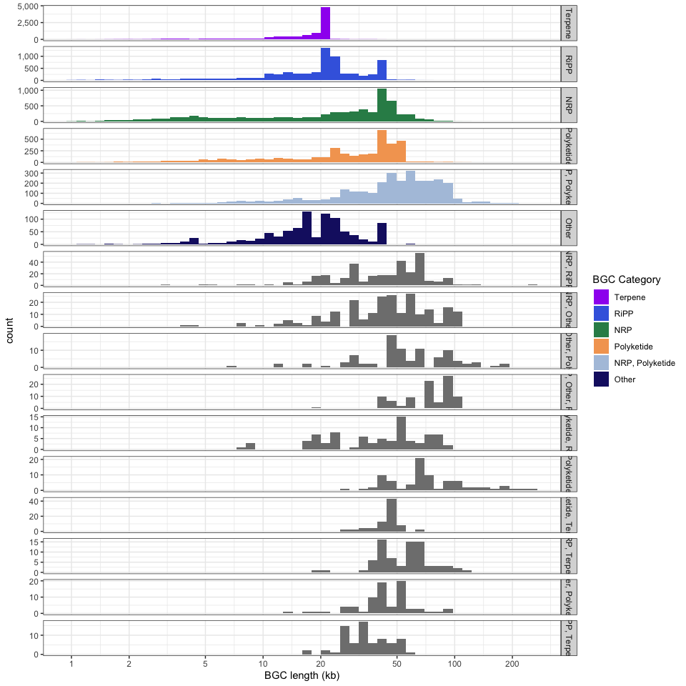

```r
category_lengths <- regions %>%
    group_by(cats_str) %>%
    filter(sum(n()) > 50) %>%
    ggplot(aes(
        x = region_length / 1000,
    )) +
        geom_histogram(aes(fill=cats_str), bins=50) +
        scale_x_log10(name = "BGC length (kb)", breaks = my_breaks / 1000, labels = label_comma()) +
        scale_y_continuous(breaks = breaks_extended(n=4), labels = label_comma()) +
        scale_fill_manual(name = "BGC Category", values = cat_colors) +
        facet_grid(rows = vars(cats_str), scales = "free_y") +
        theme_bw()
category_lengths
```

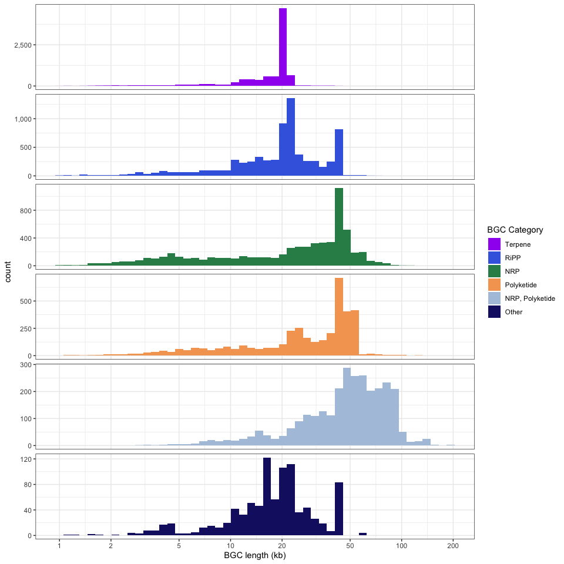

```r
ggsave("./figs/category_lengths.svg", category_lengths, device = "svg")
ggsave("./figs/category_lengths.png", category_lengths, device = "png")
category_lengths_lumped <- regions %>%
    group_by(cats_str) %>%
    filter(sum(n()) > 500) %>%
    ggplot(aes(
        x = region_length / 1000,
    )) +
        geom_histogram(aes(fill=cats_str), bins=50) +
        scale_x_log10(name = "BGC length (kb)", breaks = my_breaks / 1000, labels = label_comma()) +
        scale_y_continuous(breaks = breaks_extended(n=4), labels = label_comma()) +
        scale_fill_manual(name = "BGC Category", values = cat_colors) +
        facet_grid(rows = vars(cats_str), scales = "free_y") +
        theme_bw() +
        theme(strip.background = element_blank(),
              strip.text = element_blank())
category_lengths_lumped
```

```r
ggsave("./figs/category_lengths_lumped.svg", category_lengths_lumped, device = "svg")
ggsave("./figs/category_lengths_lumped.png", category_lengths_lumped, device = "png")
```

Stacked barplot of total BGCs divided by tax_genus

```r
regions_tax <- regions %>%
    select(region_gene_id, bgc_id, cats_str) %>%
    left_join(bgc_tax, by = "bgc_id")

tax_count <- regions_tax %>%
    group_by(tax_genus, cats_str) %>%
    summarize(num_bgcs = n()) %>%
    mutate(tax_genus = tax_genus %>% fct_reorder(num_bgcs)) %>%
    left_join(lump_groups, by = "cats_str")
```

[figure not shown]

```r
# tax_count %>%
#     group_by(tax_genus, group) %>%
#     summarize(grp_count = sum(num_bgcs), .groups = 'drop') %>%
#     group_by(tax_genus) %>%
#     mutate(genus_count = sum(grp_count)) %>%
#     filter(sum(grp_count) > 0) %>% ungroup() %>%
#     ggplot(aes(x = fct_reorder(tax_genus, genus_count, .desc = TRUE))) +
#         geom_col(aes(y = grp_count, fill = group), position = position_stack(reverse = TRUE)) +
#         scale_y_continuous(name = "BGC count", breaks = seq(0,4500,500)) +
#         scale_x_discrete(name = "Genus") +
#         scale_fill_manual(name = "BGC Category", values = cat_colors) +
#         coord_flip() +
#         theme_bw() +
#         guides()

p_all <- tax_count %>%
    group_by(tax_genus) %>%
    filter(sum(num_bgcs) > 0) %>%
    ggplot(aes(x = fct_infreq(tax_genus, w = num_bgcs))) +
        geom_col(aes(y = num_bgcs, fill = group), position = position_stack(reverse = TRUE)) +
        scale_y_continuous(name = "BGC count", breaks = seq(0,4500,500)) +
        scale_x_discrete(name = "Genus") +
        scale_fill_manual(name = "BGC Category", values = cat_colors) +
        coord_flip() +
        theme_bw() +
        ggtitle("(all genera)")
p_all
ggsave("./figs/genus_counts_all.svg", p_all, device = "svg")
ggsave("./figs/genus_counts_all.png", p_all, device = "png")
```

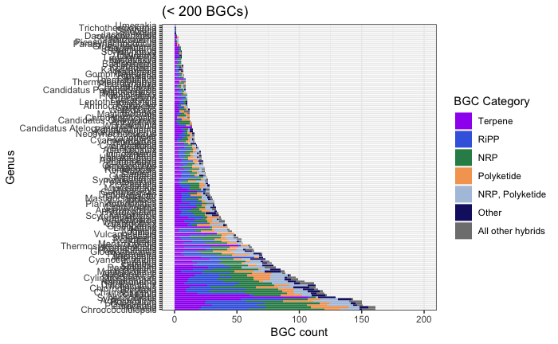

```r
p_200 <- tax_count %>%
    group_by(tax_genus) %>%
    filter(sum(num_bgcs) < 200) %>%
    ggplot(aes(x = fct_infreq(tax_genus, w = num_bgcs))) +
        geom_col(aes(y = num_bgcs, fill = group), position = position_stack(reverse = TRUE)) +
        scale_fill_manual(name = "BGC Category", values = cat_colors) +
        scale_y_continuous(name = "BGC count", breaks = seq(0,200,50), limits = c(0,200)) +
        scale_x_discrete(name = "Genus") +
        coord_flip() +
        theme_bw() +
        ggtitle("(< 200 BGCs)")
p_200
ggsave("./figs/genus_counts_200.svg", p_200, device = "svg")
ggsave("./figs/genus_counts_200.png", p_200, device = "png")
```

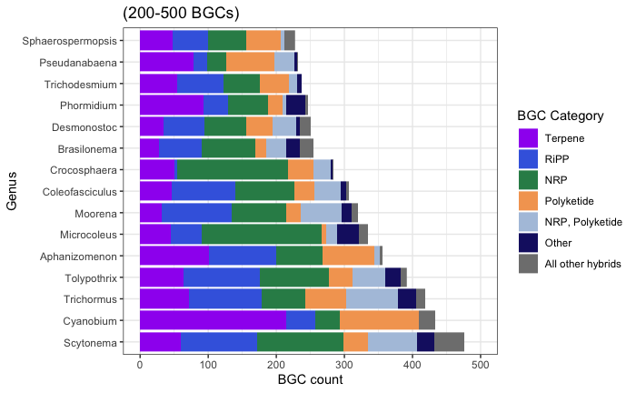

```r
p_200_500 <- tax_count %>%
    group_by(tax_genus) %>%
    filter(sum(num_bgcs) > 200 & sum(num_bgcs) < 500) %>%
    ggplot(aes(x = fct_infreq(tax_genus, w = num_bgcs))) +
        geom_col(aes(y = num_bgcs, fill = group), position = position_stack(reverse = TRUE)) +
        scale_y_continuous(name = "BGC count", limits = c(0,500), breaks = seq(0,500,100)) +
        scale_x_discrete(name = "Genus") +
        scale_fill_manual(name = "BGC Category", values = cat_colors) +
        coord_flip() +
        theme_bw() +
        ggtitle("(200-500 BGCs)")
p_200_500
ggsave("./figs/genus_counts_200_500.svg", p_200_500, device = "svg")
ggsave("./figs/genus_counts_200_500.png", p_200_500, device = "png")
```

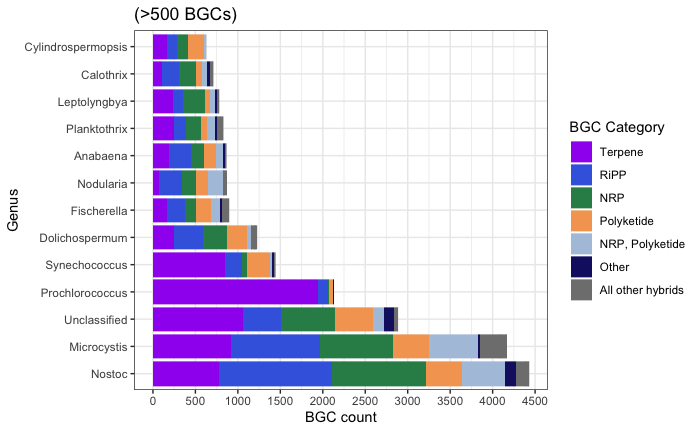

```r
p_500 <- tax_count %>%
    group_by(tax_genus) %>%
    filter(sum(num_bgcs) > 500) %>%
    ggplot(aes(x = fct_infreq(tax_genus, w = num_bgcs))) +
        geom_col(aes(y = num_bgcs, fill = group), position = position_stack(reverse = TRUE)) +
        scale_y_continuous(name = "BGC count", breaks = seq(0,4500,500)) +
        scale_x_discrete(name = "Genus") +
        scale_fill_manual(name = "BGC Category", values = cat_colors) +
        coord_flip() +
        theme_bw() +
        ggtitle("(>500 BGCs)")
p_500
ggsave("./figs/genus_counts_500plus.svg", p_500, device = "svg")
ggsave("./figs/genus_counts_500plus.png", p_500, device = "png")
```

# SMC BGCs (AS-only)

```r
as_smc_bgcs
```

[output not shown]

```r
as_bgc_summary <- as_smc_bgcs %>%
    group_by(bgc_category) %>%
    mutate(n = n()) %>%
    group_by(bgc_category, n) %>%
    summarize_at(.vars = vars(smc_bgc_length), .funs = list(min = min, max = max, mean = mean, sd = sd))

as_bgc_summary %>% arrange(desc(n))
```

[output not shown]

```r
my_breaks <- c(1, 1000, 2000, 5000, 10000, 20000, 50000, 100000, 200000, 500000)

as_bgc_hist <- ggplot(as_smc_bgcs, aes(
    x = smc_bgc_length / 1000,
)) +
    geom_histogram(aes(fill=bgc_category), bins=50) +
    scale_x_log10(name = "BGC length (kb)", breaks = my_breaks / 1000, labels = label_comma()) +
    scale_y_continuous(breaks = breaks_extended(n=4), labels = label_comma()) +
    facet_grid(rows = vars(bgc_category), scales = "free_y") +
    theme_bw() +
    guides(fill=FALSE)
as_bgc_hist
ggsave("./figs/as_bgc_hist.svg", as_bgc_hist, device = "svg")
ggsave("./figs/as_bgc_hist.png", as_bgc_hist, device = "png")
```

[output not shown]

# Protoclusters

```r
proto_summary <- protos %>%
    group_by(proto_category) %>%
    mutate(n = n()) %>%
    group_by(proto_category, n) %>%
    summarize_at(.vars = vars(proto_length), .funs = list(min = min, max = max, mean = mean, sd = sd))

proto_summary
```

[output not shown]

```r
my_breaks <- c(1, 1000, 2000, 5000, 10000, 20000, 50000, 100000, 200000, 500000)

proto_hist <- ggplot(protos, aes(
    x = proto_length / 1000,
)) +
    geom_histogram(aes(fill=proto_category), bins=50) +
    scale_x_log10(name = "Protocluster length (kb)", breaks = my_breaks / 1000, labels = label_comma()) +
    scale_y_continuous(breaks = breaks_extended(n=4), labels = label_comma()) +
    facet_grid(rows = vars(proto_category), scales = "free_y") +
    theme_bw()
proto_hist
ggsave("./figs/proto_hist.svg", proto_hist, device = "svg")
ggsave("./figs/proto_hist.png", proto_hist, device = "png")
```

[output not shown]

```r
proto_hist <- ggplot(protos, aes(
    x = proto_length / 1000,
    # y = proto_category
)) +
    geom_histogram(aes(fill=proto_category), bins=50) +
    scale_x_log10(name = "Protocluster length (kb)", breaks = my_breaks / 1000, labels = label_comma()) +
    scale_y_continuous(breaks = breaks_extended(n=4), labels = label_comma()) +
    # facet_grid(rows = vars(proto_category), scales = "free_y") +
    facet_wrap(vars(proto_category), ncol = 2, scales = "free_y") +
    theme_bw()
proto_hist
```

[output not shown]